# Arranging and composing multiple Plots

9/23/2020

## merging multiple disrincr plots

- up until now, we have been creating individual plots. Now we’re going to learn how to combine different plots into a uniform layout, using the `patchwork` library

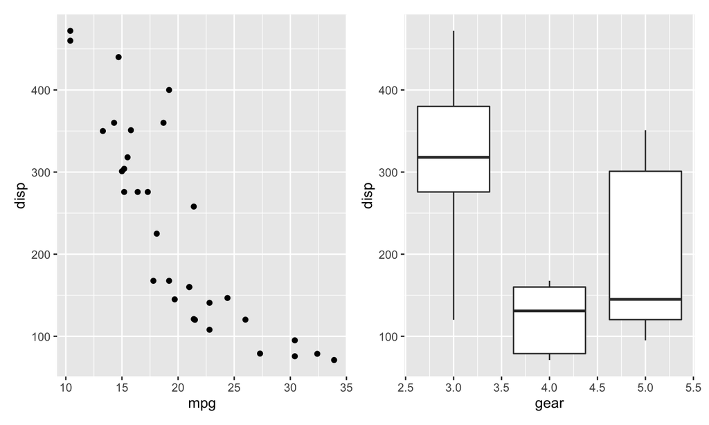

```r
library(ggplot2)
library(patchwork)
p1 <- ggplot(mtcars) + geom_point(aes(mpg, disp))
p2 <- ggplot(mtcars) + geom_boxplot(aes(gear, disp, group = gear))
p1 + p2
```

## combining plots

- the `+` operator is the simplest way to arrange plots. It adds plots, together, and tries to uniformly place plots across the square grid.

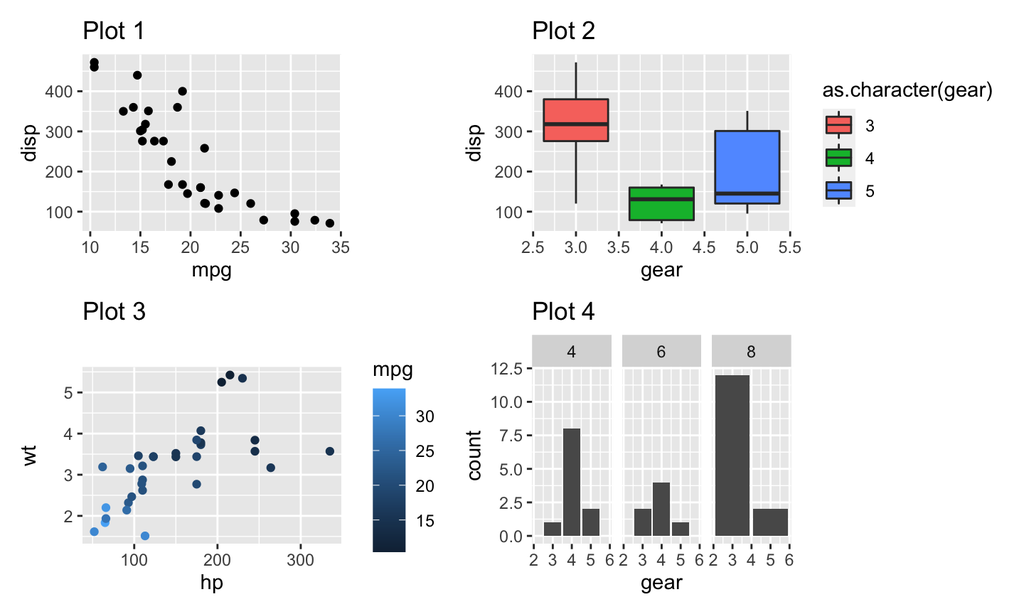

```r
p1 <- ggplot(mtcars) +
  geom_point(aes(mpg, disp,)) +
  ggtitle('Plot 1')

p2 <- ggplot(mtcars) +
  geom_boxplot(aes(gear, disp, group = gear, fill=as.character(gear))) +
  ggtitle('Plot 2')

p3 <- ggplot(mtcars) +
  geom_point(aes(hp, wt, colour = mpg)) +
  ggtitle('Plot 3')

p4 <- ggplot(mtcars) +
  geom_bar(aes(gear)) +
  facet_wrap(~cyl) +
  ggtitle('Plot 4')

p1 + p2 + p3 + p4
```

- to manually put plots to the side , use the `|`

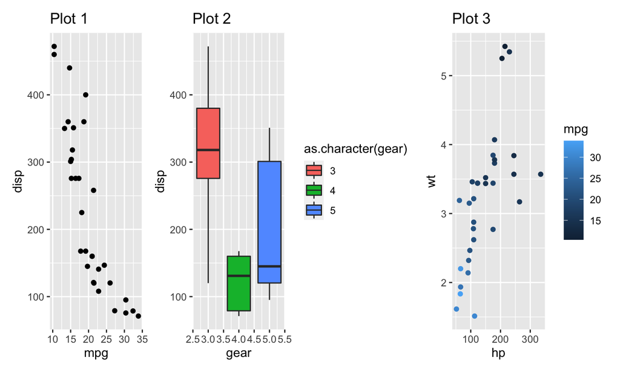

```r
p1|p2|p3
```

- similarly, but vertical, use ‘/’

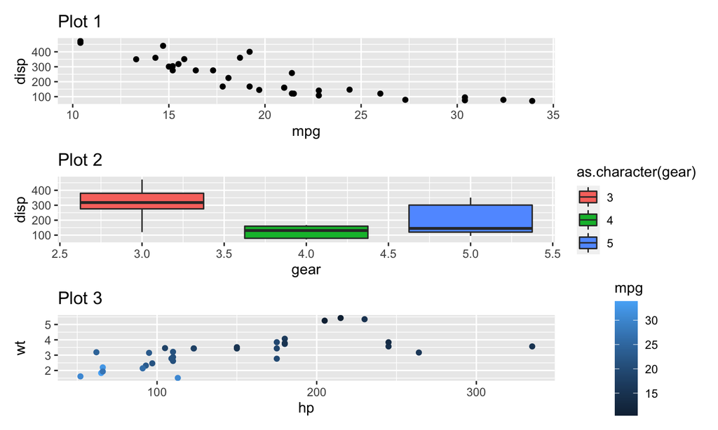

```r
p1 / p2 /p3
```

- these options can be nested , using parathenses

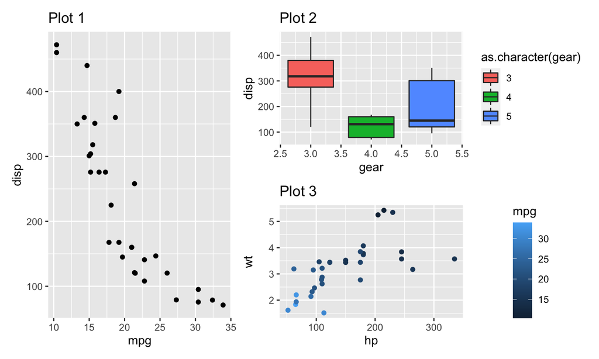

```r
p1 |(p2 /p3)
```

- or can be chained iteratively

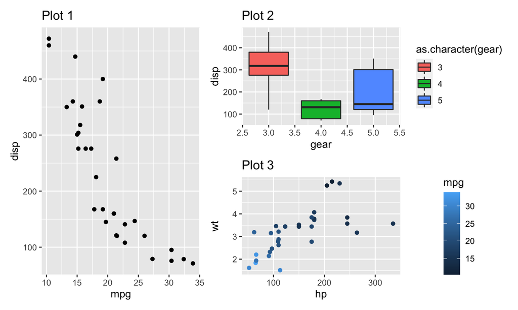

```r
sp <- p2 /p3
p1 |  sp
```

- the `plot_layout` function is used to provide greater control to the arrangement of plots. When using the plot_layout function, first combine plots using the `+` operator, and then controls the arrangement using plot_layout
- the number of rows and columns can be set with `nrow` or `ncol`

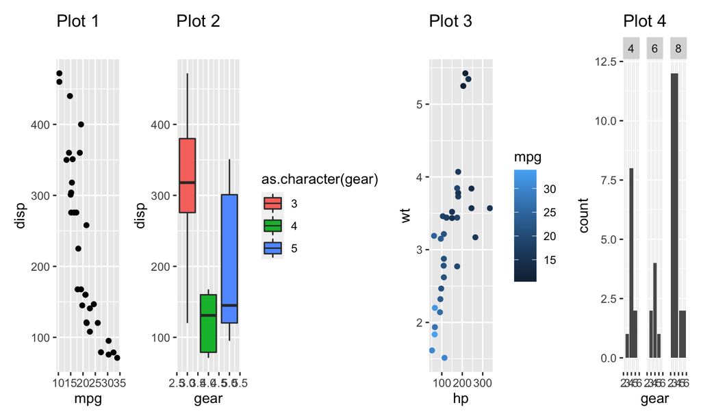

```r
p1 + p2 + p3 + p4 + plot_layout(nrow=1)
```

- but whats most useful is created a custom layout, usign the designed. I create layout vector, `des`.

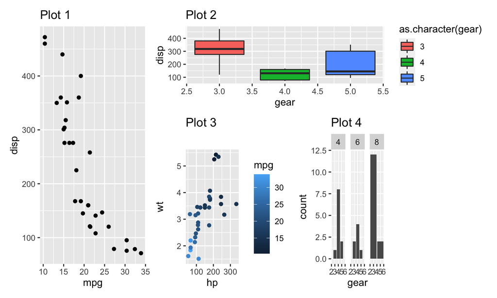

```r
des <- '
AABB
AACD
AACD'
p1 + p2 + p3 + p4 + plot_layout(design = des )
```

- the design vector must be rectangular
- ‘#’ can be used to create an empty space

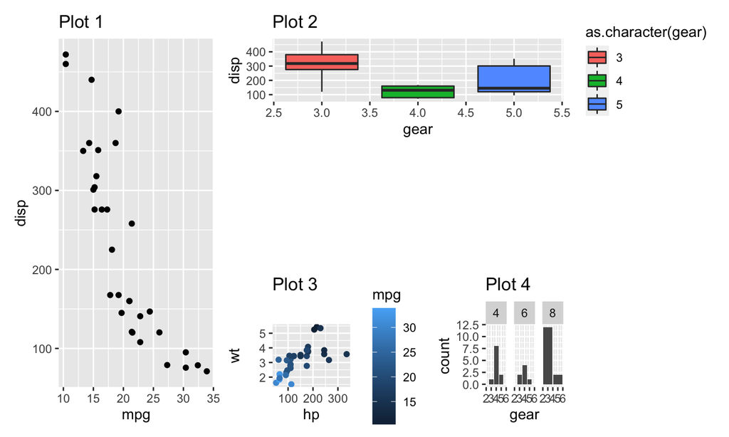

```r
des <- '
AABB
AA##
AA##
AACD'

p1 + p2 + p3 + p4 + plot_layout(design = des )
```

- finally, we can adjust the location of legends, by specifying `guides = 'collect'`

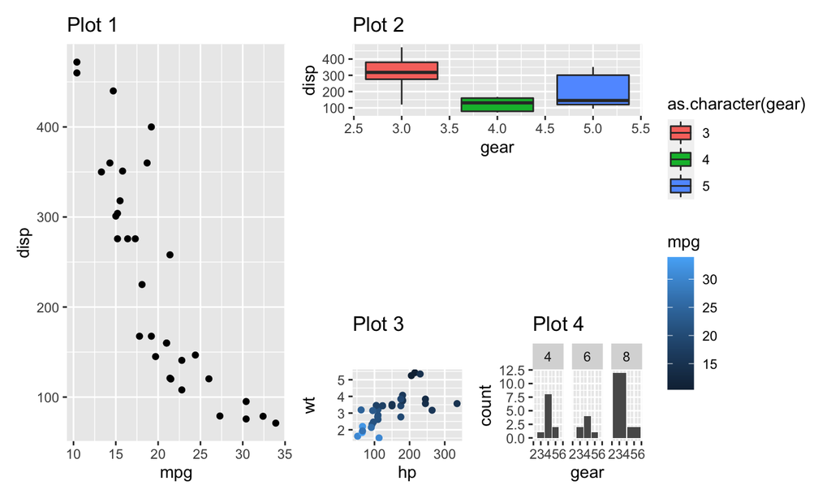

```r
p1 + p2 + p3 + p4 + plot_layout(design = des, guides = 'collect' )
```

## globally modifying plot paramters

- a very handy feature of `patchwork` is that we can change settings in `theme` for all plots

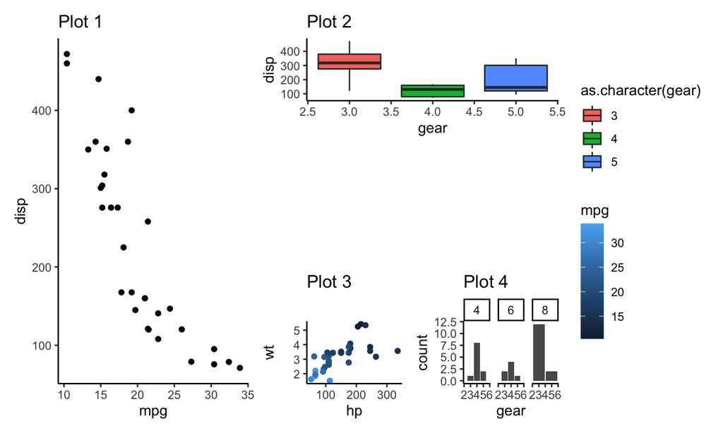

```r
p1 + p2 + p3 + p4 + plot_layout(design = des, guides = 'collect' ) & theme_classic()
```

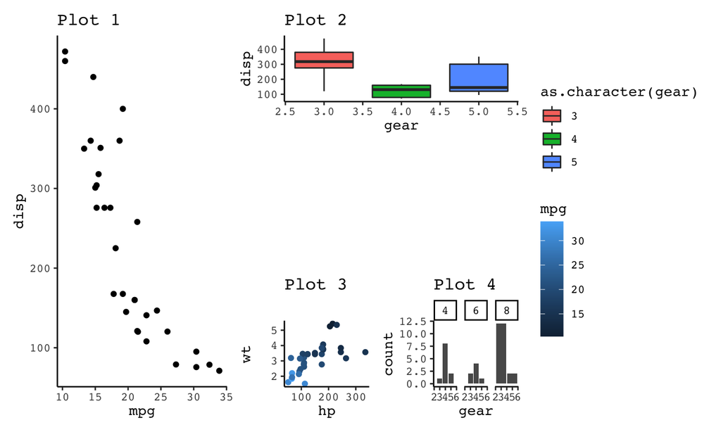

```r
p1 + p2 + p3 + p4 + plot_layout(design = des, guides = 'collect' ) & theme_classic() & theme(text = element_text('mono'))
```

- or to fix the justification of legends , and remove titles

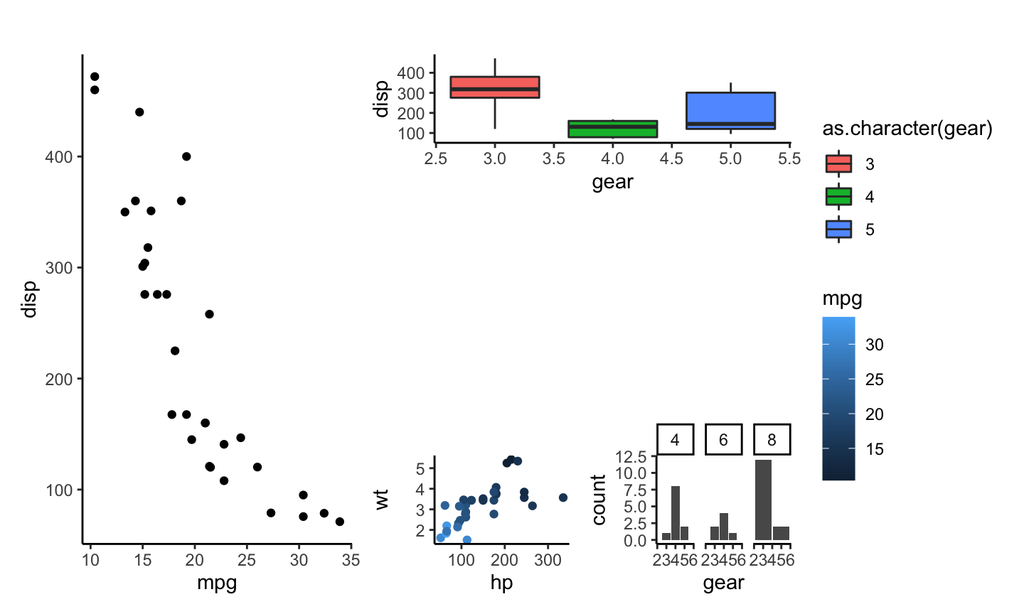

```r
all_plots <- p1 + p2 + p3 + p4 + plot_layout(design = des, guides = 'collect' ) & theme_classic() & theme(legend.box.just  = 'left') & ggtitle('')
all_plots
```

## Annotating patchworks

- the `plot_annotation` allows us to add some basic annotation to plots - like `tag_level`, which adds subfigure headings

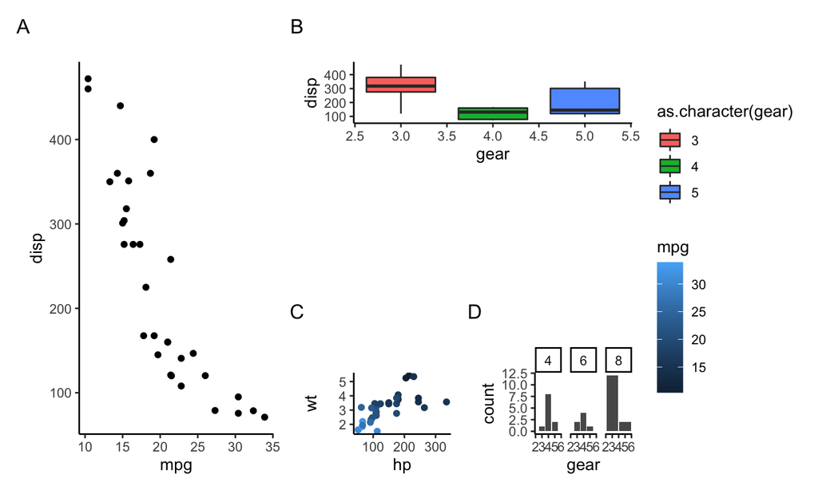

```r
all_plots + plot_annotation(tag_levels = 'A')
```

## using non-`ggplot` plots in patchwork

- unfortunately, only plots made with `ggplot` are compatible with patchwork.
- Thankfully, there’s another package `ggplotify` that will convery any plot into a ggplot

```r
library(ComplexHeatmap)
nr1 = 4; nr2 = 8; nr3 = 6; nr = nr1 + nr2 + nr3
nc1 = 6; nc2 = 8; nc3 = 10; nc = nc1 + nc2 + nc3
mat = cbind(rbind(matrix(rnorm(nr1*nc1, mean = 1,   sd = 0.5), nr = nr1),
          matrix(rnorm(nr2*nc1, mean = 0,   sd = 0.5), nr = nr2),
          matrix(rnorm(nr3*nc1, mean = 0,   sd = 0.5), nr = nr3)),
    rbind(matrix(rnorm(nr1*nc2, mean = 0,   sd = 0.5), nr = nr1),
          matrix(rnorm(nr2*nc2, mean = 1,   sd = 0.5), nr = nr2),
          matrix(rnorm(nr3*nc2, mean = 0,   sd = 0.5), nr = nr3)),
    rbind(matrix(rnorm(nr1*nc3, mean = 0.5, sd = 0.5), nr = nr1),
          matrix(rnorm(nr2*nc3, mean = 0.5, sd = 0.5), nr = nr2),
          matrix(rnorm(nr3*nc3, mean = 1,   sd = 0.5), nr = nr3))
   )
mat = mat[sample(nr, nr), sample(nc, nc)] # random shuffle rows and columns
rownames(mat) = paste0("row", seq_len(nr))
colnames(mat) = paste0("column", seq_len(nc))
hm <- Heatmap(mat)
class(hm)
```

```
## [1] "Heatmap"
## attr(,"package")
## [1] "ComplexHeatmap"
```

```r
library(ggplotify)

hm_ggplot <- as.ggplot(hm)
class(hm_ggplot)
```

```
## [1] "gg"     "ggplot"
```

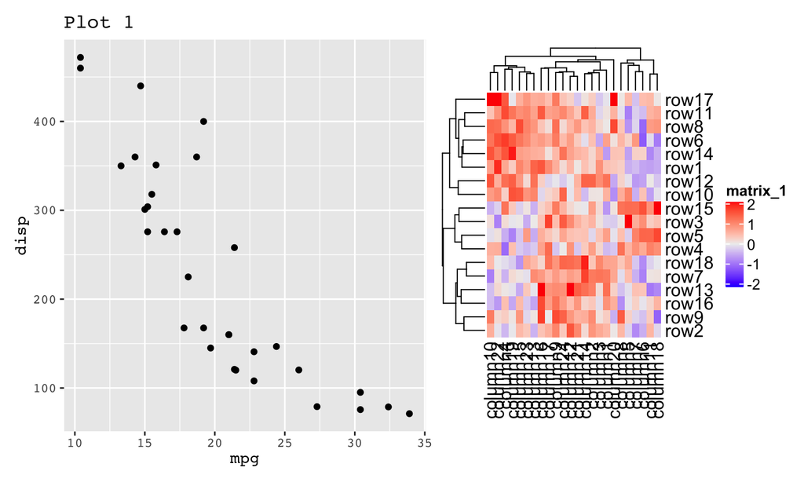

```r
p1+hm_ggplot &theme(text = element_text('mono'))
```

## Summary

- Patchwork is a useful library for arranging and assembling plots